# Clasificadores

*Víctor Bucheli Guerrero* *Universidad del Valle* *Mayo 24 / 2018*

En las regresiones lineales:

- La información es modelada para ajustarse a una línea.
- Usualmente usa el método del mínimo cuadrado para ajustarse a la línea.
- Usada para predecir valores continuos.

Los valores continuos pertenecen a una variable, por ejemplo:

Tenemos X que representa la velocidad de un carro en un momento dado y Y que representa el tiempo que toma detenerse dicho carro (X,Y). La regresión lineal sería usada para predecir el valor de Y para un X dado según un conjuto de datos.

Para realizar la regresión del ejemplo anterior vamos a tomar como ejemplo el dataframe *cars* que está integrado en R.

```r
cars #Cars viene sólo con dos columnas que representan
```

```
   speed dist
1      4    2
2      4   10
3      7    4
4      7   22
5      8   16
6      9   10
7     10   18
8     10   26
9     10   34
10    11   17
11    11   28
12    12   14
13    12   20
14    12   24
```

[output cut: 36 more lines]

```r
     # speed - velocidad en un momento dado mph, dist = distancia que toma detenerse dicho carro. ft
#Si queremos conocer más del dataframe utilizamos
help(cars)
```

## Análisis Gráfico

Para realizar nuestra regresión lineal correctamente, establecer una relación lineal estadísticamente significativa, tenemos que entender como están distribuidos nuestros datos.

Antes de continuar vamos a definir dos conceptos, - respuesta: es la variable que queremos predecir, en general Y. - predictor: variable que nos da la información para predecir, en general X.

### Gráfico de Dispersión

El gráfico de dispersón nos ayuda a determinar la relación entre las dos variables, la respuesta el predictor. Si hay más de un predictor gráficamos cada uno con la respuesta.

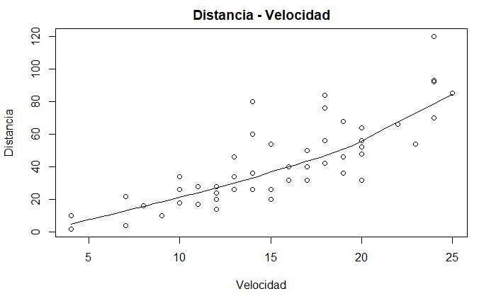

```r
scatter.smooth(x=cars$speed, y=cars$dist, main="Distancia - Velocidad", xlab = "Velocidad", ylab = "Distancia")
```

Podemos observar una relación lineal creciente, esto es algo positivo porque una de las suposiciones en las regresiones lineales es que la relación es lineal y positiva.

### Diagrama de cajas y bigotes

Mediante el diagrama de cajas y bigotes observamos los valores atípicos que pueden traer malos resultados.

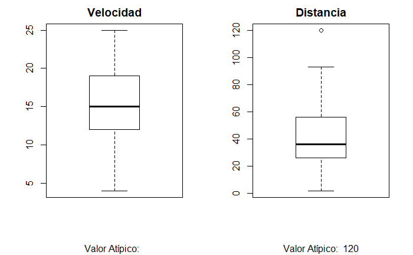

```r
par(mfrow=c(1, 2))#Obtenemos las dos gráficas en el mismo cuadro de respuesta.
boxplot(cars$speed, main="Velocidad", sub=paste("Valor Atípico: ", boxplot.stats(cars$speed)$out))  #Diagrama para velocidad
boxplot(cars$dist, main="Distancia", sub=paste("Valor Atípico: ", boxplot.stats(cars$dist)$out))  #Diagrama para la distancia
```

### Diagrama de densidad

El diagrama de densidad nos permite determinar si la distribución de cada una de las variables involucradas es normal.

```r
#install.packages('e1071', dep = TRUE)
library(e1071)
par(mfrow=c(1, 2))#Obtenemos las dos gráficas en el mismo cuadro de respuesta.
plot(density(cars$speed), main="Diagrama: Velocidad", ylab="Frecuencia")# Diagrama para velocidad
polygon(col="red")
```

[output not shown]

```
Error in xy.coords(x, y, setLab = FALSE) :
  argument "x" is missing, with no default
```

### Correlación

Es muy importante la correlación para una regresión lineal, nos permite determinar si las variables son dependientes entre sí, podemos notar que la velocidad crece junto con la distancia.

```r
cor(cars$speed, cars$dist)
```

```
[1] 0.8068949
```

La correlación está entre 1 y -1, siendo 1 una correlación total y -1 siendo una correlación nula. Determinamos que el predictor y la respuesta están muy correlacionados.

### Modelo Relacional

Podemos determinar la variable respuesta mediante la formula

#### *Y=β1+β2*X+ϵ*

Donde *β1* es el intercepto, *β2* es la pendiente, *X* es el valor conocido y *ϵ* es el término del error.

Tenemos que crear un modelo relacional y para eso vamos a utilizar la función lm.

```r
#lm se puede utilizar especificando el vector directamente o pasando el conjunto de datos y el nombre de las variables.
#modeloLineal <- lm(dist ~ speed, data = cars)
modeloLineal <- lm(cars$dist ~ cars$speed)
```

# Predición

Mediante la función predict podemos predecir un nuevo valor para la variable respuesta.

La función predict recibe como parametros el modelo y un vector con los datos a retornar.

```r
#El vector predictor.
x <- cars$speed
#El vector respuesta.
y <- cars$dist
#Aplicamos la función con los vectores
relation <- lm(y~x)
#Encontramos la distancia de frenado para una persona con una velocidad de 24.3
datoNuevo <- data.frame(x = 24.3)
datoNuevo
```

```
     x
1 24.3
```

```r
resultado <-  predict(relation,datoNuevo)
print(resultado)
```

```
       1
77.97844
```

```r
#Para más datos
datosNuevo <- data.frame(x = c(24.3, 25.5,100,1,54.6))
datosNuevo
```

```
      x
1  24.3
2  25.5
3 100.0
4   1.0
5  54.6
```

```r
resultado <-  predict(relation,datosNuevo)
print(resultado)
```

```
        1         2         3         4         5
 77.97844  82.69733 375.66178 -13.64669 197.13042
```

### Gráfica

[figure not shown]

```r
#Imprimimos la gráfica
plot(cars$dist,cars$speed,col = "red",main = "Regresión Lineal", abline(lmMod),cex = 1.3,pch = 16,xlab = "Velocidad en mph",ylab = "Distancia en ft")
```

### Referencias

- http://r-statistics.co/Linear-Regression.html